# Знакомство с Cisco Packet Tracer

Лабораторная работа №1

Гафоров Нурмухаммад

Российский университет дружбы народов, Москва, Россия

10.02.2026

# Цель работы

## Цель

Изучение принципов передачи данных в локальной сети  
с использованием Cisco Packet Tracer.

# Ход выполнения

## Создание топологии с концентратором

- Размещён Hub-PT и 4 ПК
- Устройства соединены прямыми кабелями
- Настроены IP-адреса:
  - 192.168.1.11–192.168.1.14

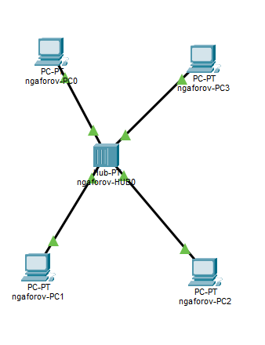

Топология с концентратором

## Передача пакетов

- Создан PDU: PC0 → PC2
- Наблюдение ARP и ICMP
- Отслежено движение пакетов

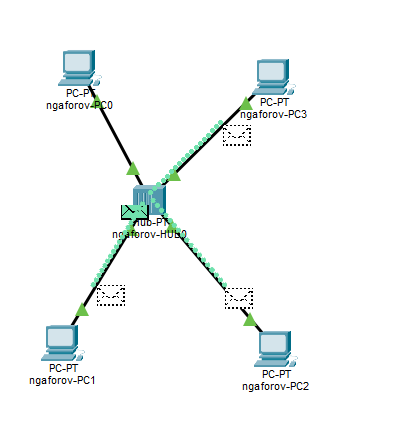

Передача ARP и ICMP

## Особенности Hub

- Работает на физическом уровне
- Передаёт сигнал на все порты
- MAC-адреса не анализируются

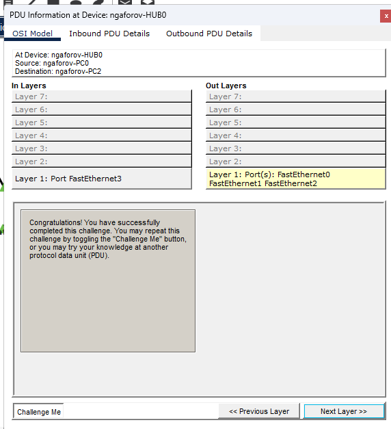

Модель OSI в Hub

## Коллизии

- Созданы два одновременных обмена
- Возникло столкновение сигналов
- Повреждение кадров и повторная передача

[figure not shown]

Коллизии в сети с Hub

## Новая топология с коммутатором

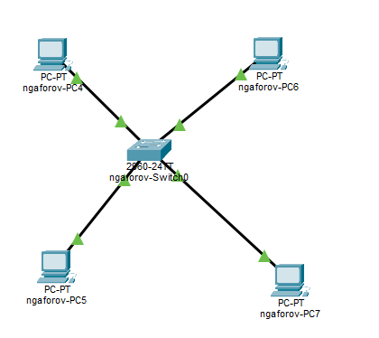

Топология с коммутатором

## Передача данных

- PDU: PC4 → PC6
- Наблюдение ARP и ICMP
- Коммутатор запоминает MAC-адреса

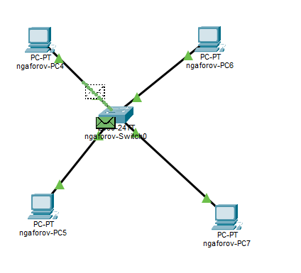

Передача через switch

## Отличия от концентратора

- Кадры отправляются только на нужный порт
- Уменьшение сетевой нагрузки
- Отсутствие коллизий

[figure not shown]

Одновременная передача без коллизий

## Соединение Hub и Switch

- Hub соединён со switch
- Выполнен обмен PC0 ↔︎ PC4

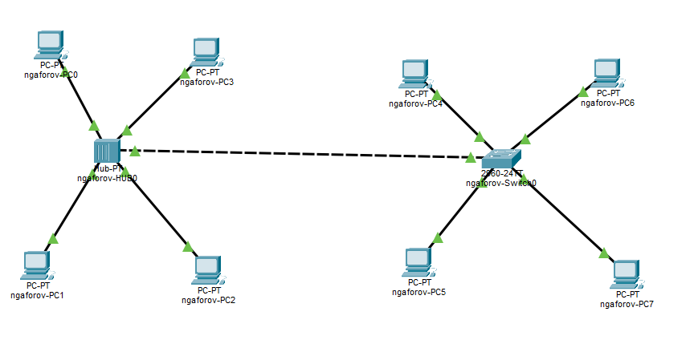

Объединённая сеть

## Поведение сети

- Сначала возникает коллизия
- Затем повторная передача
- Пакеты успешно достигают цели

[figure not shown]

Коллизия и успешная доставка

## Протокол STP

- Получены служебные STP-пакеты
- Формат Ethernet 802.3
- Используется групповой MAC-адрес

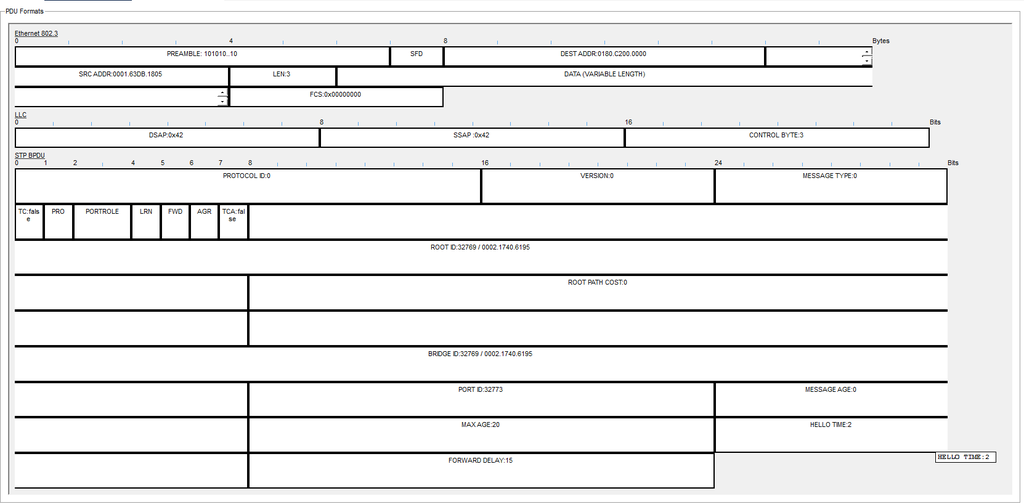

Структура STP

## Настройка Router

- Подключён к коммутатору
- Назначен IP:
  - 192.168.1.254 /24
- Интерфейс активирован

[figure not shown]

Подключение маршрутизатора

## Передача PC → Router

- Наблюдаются ARP и ICMP
- Дополнительно фиксируются STP и CDP

[figure not shown]

Передача пакетов к маршрутизатору

## Протокол CDP

- Кадры IEEE 802.3 + SNAP
- MAC назначения:
  - 01:00:0C:CC:CC:CC
- TLV-структура данных

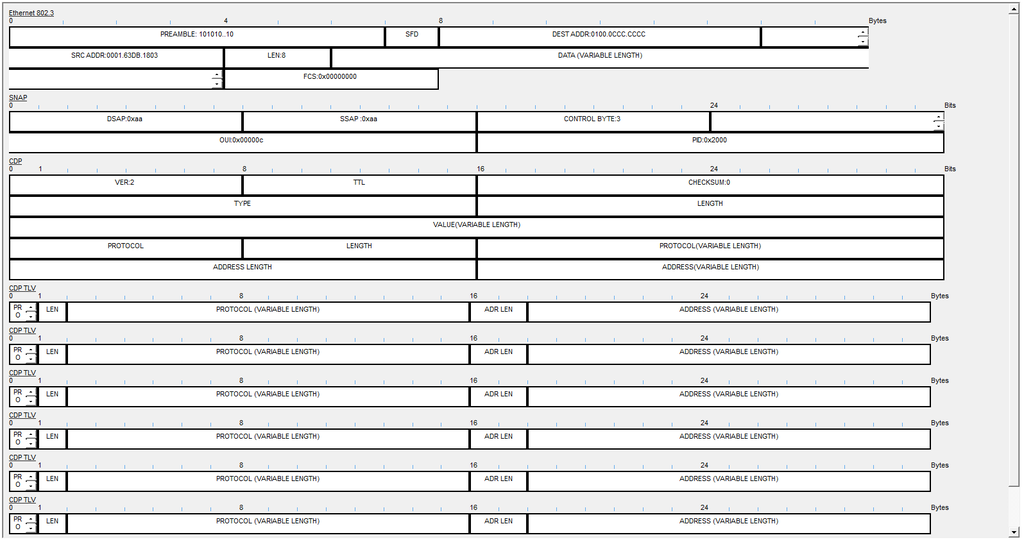

Структура CDP

# Итог

## Вывод

В ходе работы:

- Изучена передача данных в локальной сети
- Сравнена работа Hub и Switch
- Исследована маршрутизация
- Проанализированы ARP, ICMP, STP, CDP
- Рассмотрена структура Ethernet-кадров